# TimeSeries

Tanvi Arora

July 28, 2018

## Brief Financial Data

**a- Access the dataset**

```r
eustockdata.dax <- EuStockMarkets[,"DAX"]
```

Dataset used is available in R datasets - EuStockMarkets EuStockMarkets : Contains the daily closing prices of major European stock indices: Germany DAX (Ibis), Switzerland SMI, France CAC, and UK FTSE. The data are sampled in business time, i.e., weekends and holidays are omitted.

The data used is as is available from the dataset It is not normalized.

**b- Plot the data**

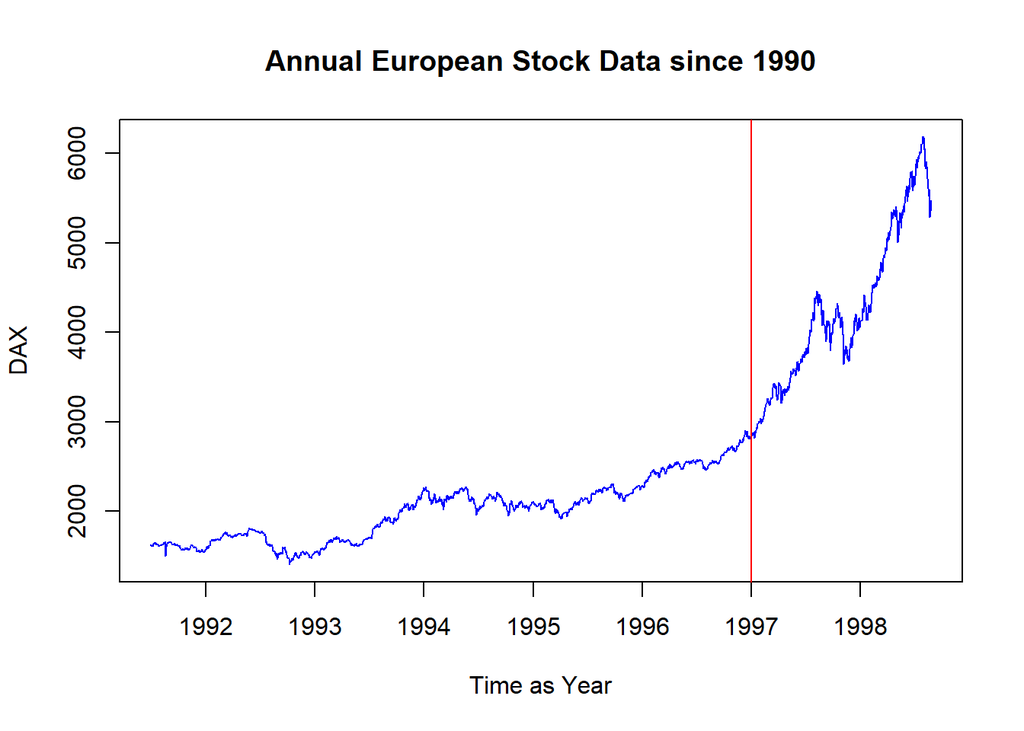

```r
plot(eustockdata.dax, col = "blue", main="Annual European Stock Data since 1990", xlab="Time as Year", ylab="DAX")

abline(v=as.numeric("1997"), col = "red")
```

**c- Decompose time-series data into its components**

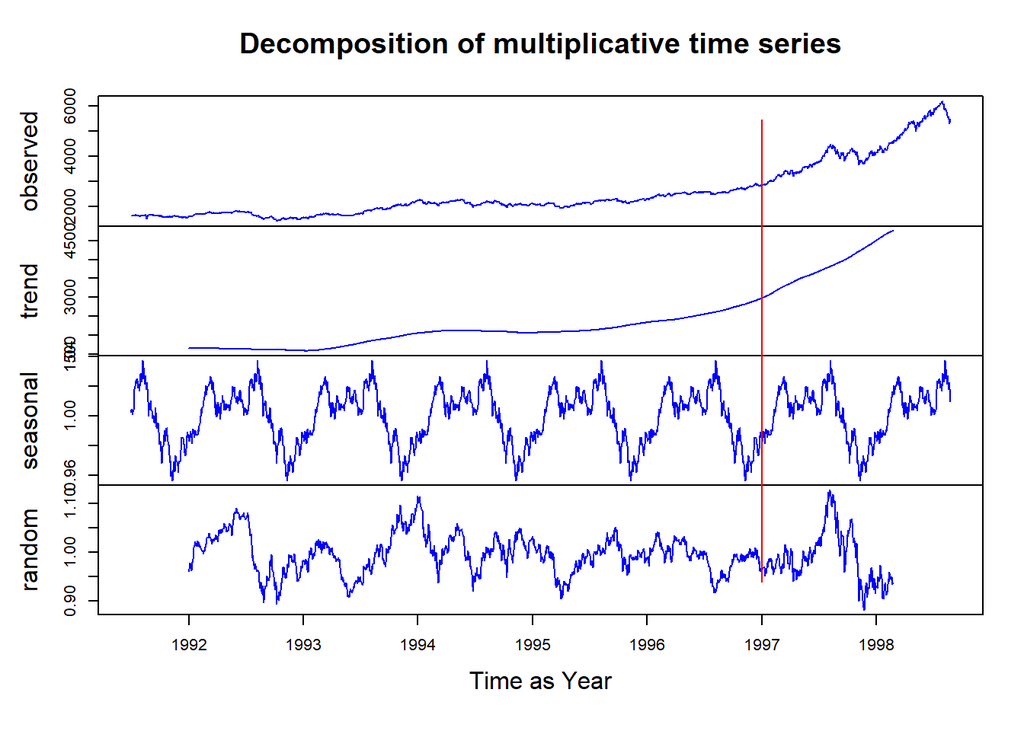

```r
eustockdata.dax.decomp <- decompose(eustockdata.dax, type="mult")
plot(eustockdata.dax.decomp, col = "blue", xlab = "Time as Year", ylab = "DAX")
abline(v=as.numeric("1997"), col = "red")
```

Above plot has timeseries decomposed into ‘observed’ , ‘trend’ , ‘seasonal’ and ‘random’ components. 1997 event line is shown in red.

## Temperature Data

**a- About the dataset**

Dataset used : maxtemp dataset granted by loading fpp2 About the dataset :

```r
help(maxtemp)
```

```
## starting httpd help server ... done
```

Maximum annual temperatures (degrees Celsius) for Moorabbin Airport, Melbourne. 1971-2016.

**b- load dataset**

Subset dataset to get data from 1990 onwards only.

```r
mt <- window(maxtemp, start=1990, end=2016)
str(mt)
```

```
##  Time-Series [1:27] from 1990 to 2016: 39 41.3 38.7 37.8 38.9 39.7 36.1 41.3 40.6 37.5 ...
##  - attr(*, "names")= chr [1:27] "1990" "1991" "1992" "1993" ...
```

**c- plot using SES**

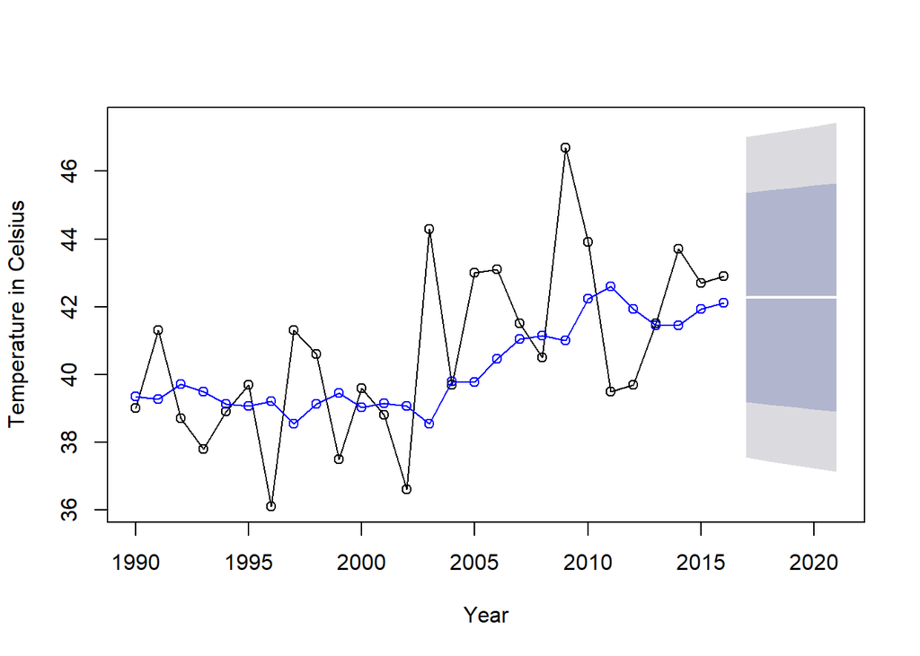

```r
# ses() or simple exponential smoothing


fit_ses <- ses(mt, h=5)
plot(fit_ses, plot.conf=FALSE, ylab="Temperature in Celsius", xlab="Year", main="", fcol="white",type="o")
lines(fitted(fit_ses), col="blue", type="o")
```

in the above plot, blue line represents fitted line through ses. Predicted temperature for next 5 years is 42.277 C.

**d- plot using holt**

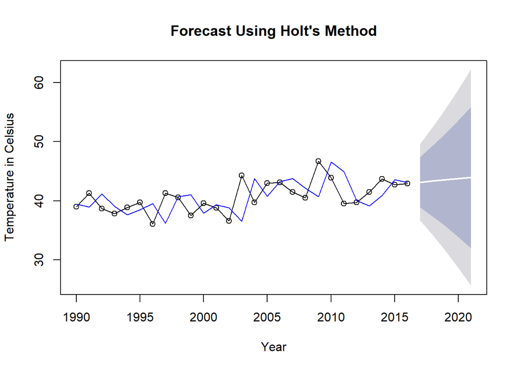

```r
# holt's linear trend method

fit_holt <- holt(mt, alpha=0.8, beta=0.2, initial="optimal",  h=5)

plot(fit_holt, type="o", ylab="Temperature in Celsius", xlab="Year", fcol="white", plot.conf=FALSE, main="Forecast Using Holt's Method")
lines(fitted(fit_holt), col="blue")
```

In the above plot, blue line represents fitted line through holt. Predicted temperature for next 5 years ranges from 43.14 C to 43.94 C

**e- Compare ses() and holt() models**

*SES model stats*

```r
# summary statistics
# AIC

fit_ses$model$aic
```

```
## [1] 140.4868
```

```r
# AICC

fit_ses$model$aicc
```

```
## [1] 141.5302
```

*holt model stats*

```r
# Summary statistics
# AIC

fit_holt$model$aic
```

```
## [1] 155.334
```

```r
# AICC

fit_holt$model$aicc
```

```
## [1] 156.3775
```

We consider model with lower AICC value as a better model. From the two models above, ses() model has AICC value of 141.53 while holt() model has AICC value of 156.37

## The Wands Choose the Wizard

**a- load wands data**

```r
olli.ds <- read.csv('Data/Unit11TimeSeries_Ollivander.csv', header=F)
names(olli.ds) <- c("date_sold","olli_count")
str(olli.ds)
```

```
## 'data.frame':    48 obs. of  2 variables:
##  $ date_sold : Factor w/ 48 levels "1/1/1970","1/1/1971",..: 1 2 3 4 5 6 7 8 9 10 ...
##  $ olli_count: int  1345 1304 1168 1252 1296 1458 1443 1282 1450 1338 ...
```

```r
summary(olli.ds)
```

```
##     date_sold    olli_count
##  1/1/1970: 1   Min.   : 200
##  1/1/1971: 1   1st Qu.:1258
##  1/1/1972: 1   Median :1312
##  1/1/1973: 1   Mean   :1325
##  1/1/1974: 1   3rd Qu.:1452
##  1/1/1975: 1   Max.   :1797
##  (Other) :42
```

```r
greg.ds <- read.csv('Data/Unit11TimeSeries_Gregorovitch.csv', header=F)
names(greg.ds) <- c("date_sold","greg_count")
str(greg.ds)
```

```
## 'data.frame':    48 obs. of  2 variables:
##  $ date_sold : Factor w/ 48 levels "1/1/1970","1/1/1971",..: 1 2 3 4 5 6 7 8 9 10 ...
##  $ greg_count: int  1268 1295 1349 1298 1493 1432 1431 1291 1247 1403 ...
```

```r
summary(greg.ds)
```

```
##     date_sold    greg_count
##  1/1/1970: 1   Min.   :   0
##  1/1/1971: 1   1st Qu.: 800
##  1/1/1972: 1   Median :1189
##  1/1/1973: 1   Mean   :1049
##  1/1/1974: 1   3rd Qu.:1431
##  1/1/1975: 1   Max.   :1863
##  (Other) :42
```

**b- convert date-like field to Date class**

```r
#convert V1 from date-like variable to an actual Date class
olli.ds$olli_date_sold <- as.Date(olli.ds$date_sold, format = "%m/%d/%Y")
olli.ds.tidy <- subset(olli.ds[,c("olli_date_sold","olli_count")])
str(olli.ds.tidy)
```

```
## 'data.frame':    48 obs. of  2 variables:
##  $ olli_date_sold: Date, format: "1970-01-01" "1971-01-01" ...
##  $ olli_count    : int  1345 1304 1168 1252 1296 1458 1443 1282 1450 1338 ...
```

```r
#convert V1 from date-like variable to an actual Date class
greg.ds$greg_date_sold <- as.Date(greg.ds$date_sold, format = "%m/%d/%Y")
greg.ds.tidy <- subset(greg.ds[,c("greg_date_sold","greg_count")])
str(greg.ds.tidy)
```

```
## 'data.frame':    48 obs. of  2 variables:
##  $ greg_date_sold: Date, format: "1970-01-01" "1971-01-01" ...
##  $ greg_count    : int  1268 1295 1349 1298 1493 1432 1431 1291 1247 1403 ...
```

**c- Convert dataframes to xts object**

```r
# convert dataframe to an xts object
olli.xts <- xts(olli.ds.tidy, order.by=olli.ds.tidy[,1])

str(olli.xts)
```

```
## An 'xts' object on 1970-01-01/2017-01-01 containing:
##   Data: chr [1:48, 1:2] "1970-01-01" "1971-01-01" "1972-01-01" "1973-01-01" ...
##  - attr(*, "dimnames")=List of 2
##   ..$ : NULL
##   ..$ : chr [1:2] "olli_date_sold" "olli_count"
##   Indexed by objects of class: [Date] TZ: UTC
##   xts Attributes:
##  NULL
```

```r
# convert dataframe to an xts object
greg.xts <- xts(greg.ds.tidy, order.by=greg.ds.tidy[,1])

str(greg.xts)
```

```
## An 'xts' object on 1970-01-01/2017-01-01 containing:
##   Data: chr [1:48, 1:2] "1970-01-01" "1971-01-01" "1972-01-01" "1973-01-01" ...
##  - attr(*, "dimnames")=List of 2
##   ..$ : NULL
##   ..$ : chr [1:2] "greg_date_sold" "greg_count"
##   Indexed by objects of class: [Date] TZ: UTC
##   xts Attributes:
##  NULL
```

**d- Plot dygraph**

```r
wands.xts <- cbind(olli.xts, greg.xts)

dygraph(wands.xts, main="The Wands choose the Wizard", xlab="Year", ylab="count of wands sold") %>% dySeries("olli_count", drawPoints = TRUE, color = "red") %>% dySeries("greg_count", drawPoints = TRUE, color = "green") %>% dyRangeSelector(height=20) %>% dyShading(from = "1995-01-01", to = "1999-01-01") %>% dyHighlight(highlightSeriesOpts = 30)
```

[interactive chart not shown]

From above plot, red line represents from Ollivander and green line from Gregorovitch. Shaded region from 1995 to 1999 is the approximate time when Voldemort was revived.